# Assignment - Factorial ANOVA and MANOVA

Myra Jatoi

June 1, 2022

## **Question 1**

### State the formula for a factorial ANOVA model with 1 dependent variable Y and 3 factors A, B and C:

### **a.** With no interaction (main effects only)

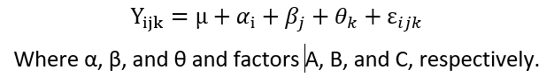

### **b.** With full interaction

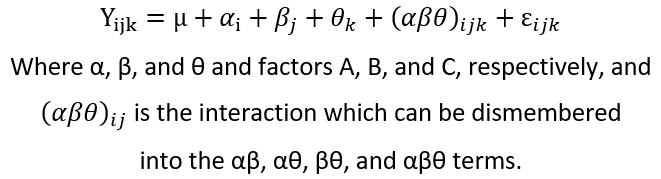

## **Question 2**

### For the data set `iris` in R, fit a MANOVA model for the dependent variables “Sepal.Length” and “Sepal.Width” against “Species”. Report both the ANOVA and MANOVA summary of the model fit.

Since there is only one factor variable (“Species”), this is then a One-Way MANOVA.

- Therefore, we claim the following hypotheses:

  H<sub>0</sub>: There is no significant difference of means across species for either sepal length or sepal width (𝛍Setosa = 𝛍Versicolor = 𝛍Virginica)

  H<sub>1</sub>: At least one of either sepal width or sepal length means differ by species type (𝛍i ≠ 𝛍j)
- Then, the significance level:

  ⍺ = 0.05 or 95% confidence level.
- Then, we check the assumptions:

  ```r
  # Calling and Checking Data
  head(datasets::iris)
  ```

  ```
  ##   Sepal.Length Sepal.Width Petal.Length Petal.Width Species
  ## 1          5.1         3.5          1.4         0.2  setosa
  ## 2          4.9         3.0          1.4         0.2  setosa
  ## 3          4.7         3.2          1.3         0.2  setosa
  ## 4          4.6         3.1          1.5         0.2  setosa
  ## 5          5.0         3.6          1.4         0.2  setosa
  ## 6          5.4         3.9          1.7         0.4  setosa
  ```

  ```r
  # Checking the Assumptions

  ## 1) Univariate Normality
  library(rstatix)
  iris %>% group_by(Species) %>% shapiro_test(Sepal.Length, Sepal.Width)
  ```

  ```
  ## # A tibble: 6 x 4
  ##   Species    variable     statistic     p
  ##   <fct>      <chr>            <dbl> <dbl>
  ## 1 setosa     Sepal.Length     0.978 0.460
  ## 2 setosa     Sepal.Width      0.972 0.272
  ## 3 versicolor Sepal.Length     0.978 0.465
  ## 4 versicolor Sepal.Width      0.974 0.338
  ## 5 virginica  Sepal.Length     0.971 0.258
  ## 6 virginica  Sepal.Width      0.967 0.181
  ```

  ```r
  ## 2) Multivariate Normality
  library(mvnormalTest)
  mardia(iris[, c("Sepal.Length", "Sepal.Width")])$mv.test
  ```

  ```
  ##           Test Statistic p-value Result
  ## 1     Skewness    9.4614  0.0505    YES
  ## 2     Kurtosis    -0.691  0.4896    YES
  ## 3 MV Normality      <NA>    <NA>    YES
  ```

  ```r
  ## 3) Homogeneity of the Variance-Covariance Matrices

  library(heplots)
  boxM(Y = iris[, c("Sepal.Length", "Sepal.Width")], group = iris$Species)
  ```

  ```
  ##
  ##  Box's M-test for Homogeneity of Covariance Matrices
  ##
  ## data:  iris[, c("Sepal.Length", "Sepal.Width")]
  ## Chi-Sq (approx.) = 35.655, df = 6, p-value = 3.217e-06
  ```

  ```r
  ## 4) Homogeneity of Variances
  library(car)
  leveneTests(iris[,1:2], iris$Species, center=mean)
  ```

  ```
  ## Levene's Tests for Homogeneity of Variance (center = mean)
  ##
  ##              df1 df2 F value    Pr(>F)
  ## Sepal.Length   2 147  7.3811 0.0008818 ***
  ## Sepal.Width    2 147  0.6006 0.5498108
  ## ---
  ## Signif. codes:  0 '***' 0.001 '**' 0.01 '*' 0.05 '.' 0.1 ' ' 1
  ```

  ```r
  ## 5) Multivariate Outliers
  m_o <- mahalanobis_distance(data = iris[, c("Sepal.Length", "Sepal.Width")])$is.outlier
  table(m_o)
  ```

  ```
  ## m_o
  ## FALSE
  ##   150
  ```

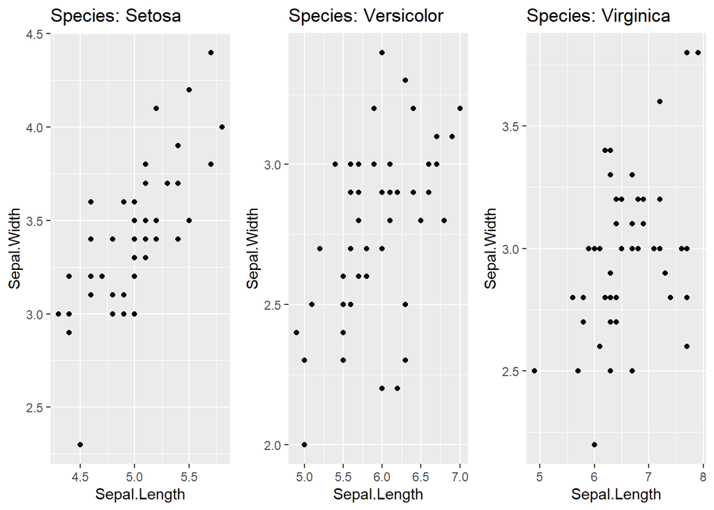

  ```r
  ## 6) Linearity by Group
  library(gridExtra)
  library(ggplot2)
  p1 <- iris  %>% group_by(Species) %>% filter(Species == "setosa") %>% ggplot(aes(x = Sepal.Length, y = Sepal.Width)) + geom_point() + ggtitle("Species: Setosa")
  p2 <- iris  %>% group_by(Species) %>% filter(Species == "versicolor") %>% ggplot(aes(x = Sepal.Length, y = Sepal.Width)) + geom_point() + ggtitle("Species: Versicolor")
  p3 <- iris  %>% group_by(Species) %>% filter(Species == "virginica") %>% ggplot(aes(x = Sepal.Length, y = Sepal.Width)) + geom_point() + ggtitle("Species: Virginica")

  grid.arrange(p1, p2, p3, ncol=3)
  ```

  ```r
  ## 7) Multicollinearity
  cor.test(x = iris$Sepal.Length, y = iris$Sepal.Width, method = "pearson")$estimate
  ```

  ```
  ##        cor
  ## -0.1175698
  ```

  As observed, a pre-check of the assumption of normality (univariate) first indicated that, overall, data follows a normal distribution (p > 0.05). In the context of MANOVA, the multivariate normality test (for both dependent variables simultaneously) would then present the same outcome (skewness/kurtosis test with p > 0.05). To check whether variance-covariance matrices are equal for each combination formed by each group in the independent variable, there was conducted a Box’s M test which accused a p-value smaller than the test standard of p > 0.001 thus violating this assumption. From that, a Levene’s homogeneity of variances test indicated that the issue relies on Sepal.Length data (i.e., variances across species are not homogeneous for this variable). Following, the assumption of multivariate outliers was checked from the Mahalanobis test which returned n = 150 “FALSE” arguments (the size of the data set) thus meaning that none of the observations are outliers. Then, to check the assumption of linearity by group, there were plotted side-by-side scatterplots and they indicate that for each species there is linearity between the two dependent variables, even though one are more scattered than others. Finally, the assumption of multicollinearity was checked from the correlation coefficient between the two dependent variables, and the value of r = -0.118 suggest a weak negative correlation that means the assumption was met (no high correlation, i.e., r > 0.9). Overall, from the 7 assumptions only one was not met (homogeneity of variance-covariance matrices) and that means we should report the Pillai’s Trace statistic because it is more robust to departures from assumptions.
- Then, we run the analysis and check effect size:

  ```r
  # Running MANOVA
  my_manova <- manova(cbind(Sepal.Length, Sepal.Width) ~ Species, data = iris)
  summary(my_manova)
  ```

  ```
  ##            Df  Pillai approx F num Df den Df    Pr(>F)
  ## Species     2 0.94531   65.878      4    294 < 2.2e-16 ***
  ## Residuals 147
  ## ---
  ## Signif. codes:  0 '***' 0.001 '**' 0.01 '*' 0.05 '.' 0.1 ' ' 1
  ```

  ```r
  # Checking Univariate ANOVAs
  summary.aov(my_manova)
  ```

  ```
  ##  Response Sepal.Length :
  ##              Df Sum Sq Mean Sq F value    Pr(>F)
  ## Species       2 63.212  31.606  119.26 < 2.2e-16 ***
  ## Residuals   147 38.956   0.265
  ## ---
  ## Signif. codes:  0 '***' 0.001 '**' 0.01 '*' 0.05 '.' 0.1 ' ' 1
  ##
  ##  Response Sepal.Width :
  ##              Df Sum Sq Mean Sq F value    Pr(>F)
  ## Species       2 11.345  5.6725   49.16 < 2.2e-16 ***
  ## Residuals   147 16.962  0.1154
  ## ---
  ## Signif. codes:  0 '***' 0.001 '**' 0.01 '*' 0.05 '.' 0.1 ' ' 1
  ```

  ```r
  # Effect Sizes
  require(effectsize)
  effectsize::eta_squared(my_manova)
  ```

  ```
  ## # Effect Size for ANOVA (Type I)
  ##
  ## Parameter | Eta2 (partial) |       95% CI
  ## -----------------------------------------
  ## Species   |           0.47 | [0.40, 1.00]
  ##
  ## - One-sided CIs: upper bound fixed at (1).
  ```

  Using a 95% confidence level, we can reject the null hypothesis because p < 0.0001 and we should claim that at least one of either sepal width or sepal length means differ by species type. The correspondent F test statistic [F(4, 294) = 65.88, p < 0.0001] suggest the same conclusion. Thus, we should conclude that species types have a statistically significant association with both combined sepal length and sepal width. The measure of effect size (Partial Eta Squared; η<sub>*p*</sub><sup>2</sup>) is 0.47 and suggests that there is a large effect of species types on both combined sepal length and sepal width, and that effect largeness is free to vary between the minimum of 0.40 and 1.00 with 95% confidence.
- Finally, we conduct post-hoc test to know were differences appear:

  ```r
  # Linear Discriminant Analysis - Post-Hoc
  library(MASS)
  post_hoc <- lda(iris$Species ~ cbind(iris$Sepal.Length, iris$Sepal.Width), CV=F)
  post_hoc
  ```

  ```
  ## Call:
  ## lda(iris$Species ~ cbind(iris$Sepal.Length, iris$Sepal.Width),
  ##     CV = F)
  ##
  ## Prior probabilities of groups:
  ##     setosa versicolor  virginica
  ##  0.3333333  0.3333333  0.3333333
  ##
  ## Group means:
  ##            cbind(iris$Sepal.Length, iris$Sepal.Width)1
  ## setosa                                           5.006
  ## versicolor                                       5.936
  ## virginica                                        6.588
  ##            cbind(iris$Sepal.Length, iris$Sepal.Width)2
  ## setosa                                           3.428
  ## versicolor                                       2.770
  ## virginica                                        2.974
  ##
  ## Coefficients of linear discriminants:
  ##                                                   LD1        LD2
  ## cbind(iris$Sepal.Length, iris$Sepal.Width)1 -2.141178 -0.8152721
  ## cbind(iris$Sepal.Length, iris$Sepal.Width)2  2.768109 -2.0960764
  ##
  ## Proportion of trace:
  ##    LD1    LD2
  ## 0.9628 0.0372
  ```

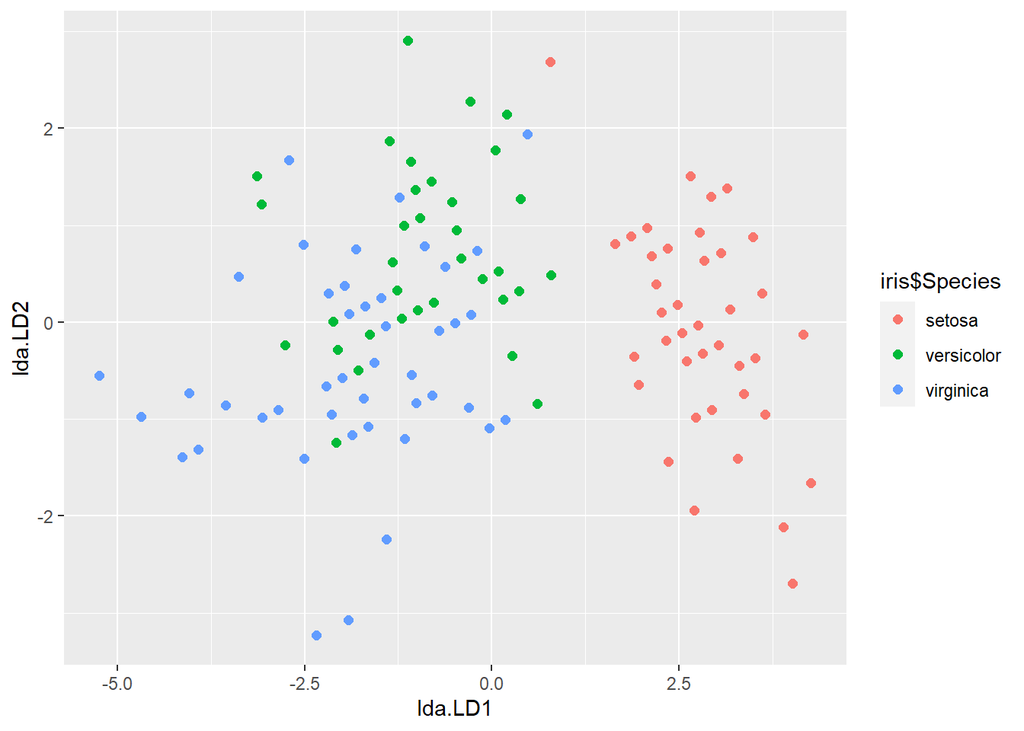

  ```r
  # Plotting Results
  plot_lda <- data.frame(iris[, "Species"], lda = predict(post_hoc)$x)
  ggplot(plot_lda) + geom_point(aes(x = lda.LD1, y = lda.LD2, colour = iris$Species), size = 2)
  ```

  By observing the post-hoc outputs, the statistics and scatterplots of the linear discriminant analysis discriminated against one species type based on the two dependent variables. That is, while Virginica and Versicolor are quite clustered together, the Setosa species has a significant difference (well separated) as compared to the others. Therefore, we should claim that Virginica and Versicolor species are more similar to each other while Setosa species is not.

## **Question 3**

### In the `genotype` data set in R studio, fit a factorial ANOVA model with full interaction for the dependent variable “Wt” against the factors “Litter” and “Mother”. Use the “?`genotype`” function to learn more about the data set.

### **a.** Is this a balanced model? Why or why not?

- To check this condition we should explore the data set using the recommended variables. For that, we should do:

  ```r
  ?genotype
  head(MASS::genotype)
  ```

  ```
  ##   Litter Mother   Wt
  ## 1      A      A 61.5
  ## 2      A      A 68.2
  ## 3      A      A 64.0
  ## 4      A      A 65.0
  ## 5      A      A 59.7
  ## 6      A      B 55.0
  ```

  ```r
  table(genotype$Litter, genotype$Mother)
  ```

  ```
  ##
  ##     A B I J
  ##   A 5 3 4 5
  ##   B 4 5 4 2
  ##   I 3 3 5 3
  ##   J 4 3 3 5
  ```

  As observed, multiple combinations of levels from both variables have different sizes thus this not a balanced design.

### **b.** Make a box plot of the dependent variable against factors. What trends do you observe?

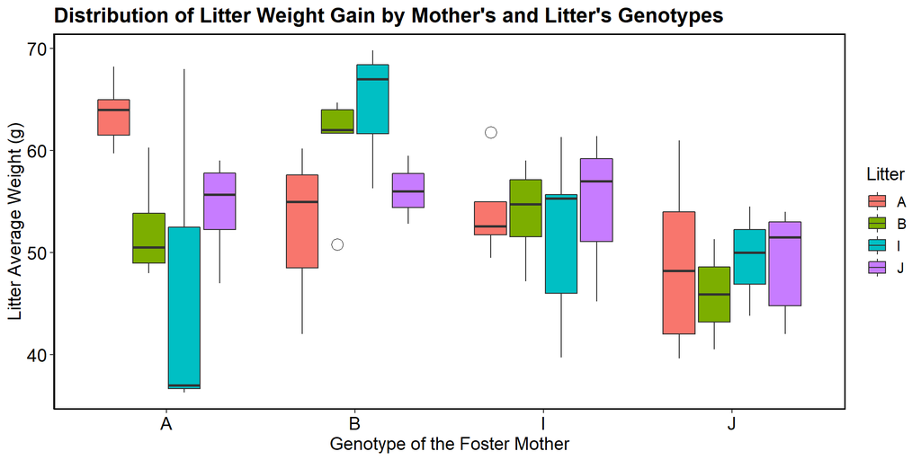

```r
plot1 <- ggplot(genotype,
                aes(x=as.factor(Mother),
                    y=as.numeric(Wt),
                    fill=Litter)) +
  geom_boxplot(outlier.colour="black",
               outlier.shape=1,
               outlier.size=4,
               na.rm = TRUE) +
  theme_classic() +
  labs(title="Distribution of Litter Weight Gain by Mother's and Litter's Genotypes",
       x="Genotype of the Foster Mother",
       y = "Litter Average Weight (g)") +
  theme(text = element_text(size=14),
        panel.border = element_rect(color = "black",
                                    fill = NA,
                                    size = 1),
        plot.title = element_text(face = "bold",
                                  size = 16),
        axis.text.x = element_text(size=14, color="black"),
        axis.text.y = element_text(size=14, color="black"));plot1
```

As observed from the two-way boxplot, there is a clear trend of different variances in weight gain from mother’s genotypes A through J. That is, the distribution of litter weight gain foster feeding mother carrying genotype A shows higher variability than foster feeding mothers with genotype B, I, and J. Expressive differences in litter weight gain seem to also be present for such genotype up to the point that for genotype J these differences seem to not evidently occur.

### **c.** Report the ANOVA results and state your conclusions from the analysis.

- First, we state the hypotheses:

  **H<sub>0</sub>:**

  There is no difference in mean weight gain across foster feeding mother’s genotypes;

  There is no difference in mean weight gain across litter’s genotypes;

  There is no difference in mean weight gain from the interaction across foster feeding mother’s genotypes and litter’s genotypes;

  **H<sub>1</sub>:**

  There is difference in mean weight gain across foster feeding mother’s genotypes;

  There is difference in mean weight gain across litter’s genotypes;

  There is difference in mean weight gain from the interaction across foster feeding mother’s genotypes and litter’s genotypes;
- Then, we establish the significance level:

  ⍺ = 0.05 or 95% confidence.
- Now, we check the main assumptions:

  ```r
  # Homogeneity of Variances
  leveneTest(Wt ~ Mother*Litter, data = genotype)
  ```

  ```
  ## Levene's Test for Homogeneity of Variance (center = median)
  ##       Df F value Pr(>F)
  ## group 15  0.4618 0.9476
  ##       45
  ```

  ```r
  # Normality
  res1 <- aov(Wt ~ Mother*Litter, data = genotype)
  shapiro.test(residuals(res1))
  ```

  ```
  ##
  ##  Shapiro-Wilk normality test
  ##
  ## data:  residuals(res1)
  ## W = 0.96673, p-value = 0.09559
  ```

- Then, we run the analysis and check the effect sizes:

  ```r
  res1 <- aov(Wt ~ Mother*Litter, data = genotype)
  Anova(res1, type="III")
  ```

  ```
  ## Anova Table (Type III tests)
  ##
  ## Response: Wt
  ##                Sum Sq Df  F value  Pr(>F)
  ## (Intercept)   20275.7  1 373.8122 < 2e-16 ***
  ## Mother          582.3  3   3.5782 0.02099 *
  ## Litter          591.7  3   3.6362 0.01968 *
  ## Mother:Litter   824.1  9   1.6881 0.12005
  ## Residuals      2440.8 45
  ## ---
  ## Signif. codes:  0 '***' 0.001 '**' 0.01 '*' 0.05 '.' 0.1 ' ' 1
  ```

  ```r
  effectsize(res1)
  ```

  ```
  ## # Effect Size for ANOVA (Type I)
  ##
  ## Parameter     | Eta2 (partial) |       95% CI
  ## ---------------------------------------------
  ## Mother        |           0.24 | [0.05, 1.00]
  ## Litter        |           0.03 | [0.00, 1.00]
  ## Mother:Litter |           0.25 | [0.00, 1.00]
  ##
  ## - One-sided CIs: upper bound fixed at (1).
  ```

- Finally, we run the post-hoc test:

  ```r
  TukeyHSD(res1, which="Mother")
  ```

  ```
  ##   Tukey multiple comparisons of means
  ##     95% family-wise confidence level
  ##
  ## Fit: aov(formula = Wt ~ Mother * Litter, data = genotype)
  ##
  ## $Mother
  ##         diff        lwr        upr     p adj
  ## B-A   3.3000  -3.890098 10.4900983 0.6148765
  ## I-A  -2.0375  -8.983795  4.9087949 0.8619897
  ## J-A  -6.7200 -13.781117  0.3411175 0.0673680
  ## I-B  -5.3375 -12.527598  1.8525983 0.2105644
  ## J-B -10.0200 -17.321088 -2.7189123 0.0035529
  ## J-I  -4.6825 -11.743617  2.3786175 0.3013830
  ```

  ```r
  TukeyHSD(res1, which="Litter")
  ```

  ```
  ##   Tukey multiple comparisons of means
  ##     95% family-wise confidence level
  ##
  ## Fit: aov(formula = Wt ~ Mother * Litter, data = genotype)
  ##
  ## $Litter
  ##            diff       lwr      upr     p adj
  ## B-A -1.97929412 -8.939196 4.980608 0.8724765
  ## I-A -2.61761555 -9.708340 4.473108 0.7587610
  ## J-A -2.02446078 -8.984363 4.935441 0.8649006
  ## I-B -0.63832143 -7.939409 6.662766 0.9954670
  ## J-B -0.04516667 -7.219269 7.128936 0.9999983
  ## J-I  0.59315476 -6.707933 7.894242 0.9963520
  ```